# Day 1: CodeTag 1: Code

R Exercises: Basics & Accumulation CurvesR-Übungen: Grundlagen & Akkumulationskurven

Ecology WorkshopÖkologie-Workshop

2026-01-25

# Exercise 1: Working with Species DataÜbung 1: Mit Artendaten arbeiten

#### Your First R Code

Let’s represent our two forests as **vectors** in R:

#### Dein erster R-Code

Stellen wir unsere zwei Wälder als **Vektoren** in R dar:

```r
# Forest A: 5 oaks
forest_a <- c("Oak", "Oak", "Oak", "Oak", "Oak")

# Forest B: 5 different species
forest_b <- c("Oak", "Beech", "Maple", "Pine", "Birch")

# How many trees?
length(forest_a)
```

```
## [1] 5
```

```r
length(forest_b)
```

```
## [1] 5
```

```r
# How many UNIQUE species?
unique(forest_a)
```

```
## [1] "Oak"
```

```r
length(unique(forest_a))
```

```
## [1] 1
```

```r
unique(forest_b)
```

```
## [1] "Oak"   "Beech" "Maple" "Pine"  "Birch"
```

```r
length(unique(forest_b))
```

```
## [1] 5
```

**Key functions:**

- `c()` - combine values into a vector
- `length()` - count elements
- `unique()` - find unique values

**Wichtige Funktionen:**

- `c()` - Werte zu einem Vektor kombinieren
- `length()` - Elemente zählen
- `unique()` - eindeutige Werte finden

# Exercise 2: Loading Real DataÜbung 2: Echte Daten laden

#### Exploring Austrian Vegetation Data

Let’s load real data from the European Vegetation Archive (EVA):

#### Österreichische Vegetationsdaten erkunden

Laden wir echte Daten aus dem European Vegetation Archive (EVA):

```r
# Load the data
species <- read.csv("../data/austria_species.csv")
plots <- read.csv("../data/austria_header.csv")

# How big is our dataset?
nrow(species)  # Number of species observations
```

```
## [1] 852075
```

```r
nrow(plots)    # Number of plots
```

```
## [1] 52526
```

```r
# Look at the first few rows
head(species)
```

```
##   PlotObservationID             WFO_TAXON    WFO_FAMILY STATUS
## 1            390844   Aconitum lycoctonum Ranunculaceae native
## 2            390844   Agrostis capillaris       Poaceae native
## 3            390844   Alchemilla coriacea      Rosaceae native
## 4            390844 Anthoxanthum odoratum       Poaceae native
## 5            390844  Anthyllis vulneraria      Fabaceae native
## 6            390844   Persicaria vivipara  Polygonaceae native
```

```r
# What columns do we have?
names(species)
```

```
## [1] "PlotObservationID" "WFO_TAXON"         "WFO_FAMILY"
## [4] "STATUS"
```

```r
names(plots)
```

```
## [1] "PlotObservationID" "Year"              "Longitude"
## [4] "Latitude"          "Eunis_lvl1"        "Eunis_lvl2"
## [7] "EVA_Country"
```

```r
# How many unique species?
length(unique(species$WFO_TAXON))
```

```
## [1] 2700
```

```r
# How many unique plots?
length(unique(species$PlotObservationID))
```

```
## [1] 29857
```

**Key functions:**

- `read.csv()` - load data from a file
- `head()` - see first rows
- `names()` - column names
- `nrow()` - number of rows

**Wichtige Funktionen:**

- `read.csv()` - Daten aus Datei laden
- `head()` - erste Zeilen anzeigen
- `names()` - Spaltennamen
- `nrow()` - Anzahl der Zeilen

# Exercise 3: Building Your First CurveÜbung 3: Deine erste Kurve bauen

#### Using cumsum() to Build Accumulation Curves

#### Mit cumsum() Akkumulationskurven bauen

```r
# New species found in each plot
new_species <- c(12, 8, 5, 3, 2, 2, 1, 1, 1, 0)

# Calculate cumulative sum
cumulative <- cumsum(new_species)
cumulative
```

```
##  [1] 12 20 25 28 30 32 33 34 35 35
```

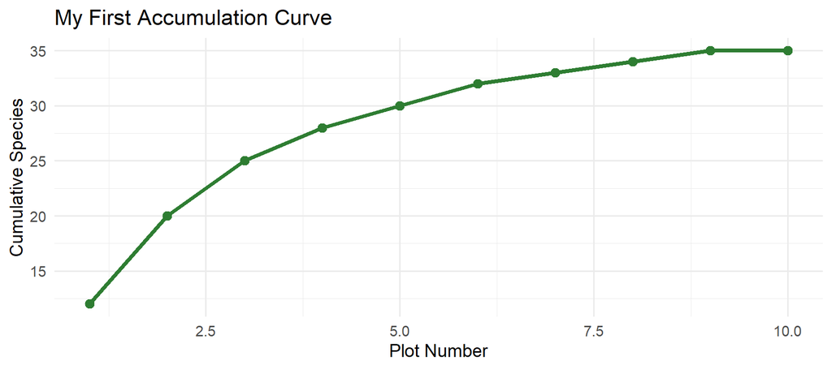

```r
# Create a data frame for plotting
curve_data <- data.frame(
  plot = 1:10,
  new = new_species,
  total = cumulative
)

# Plot the curve
ggplot(curve_data, aes(x = plot, y = total)) +
  geom_line(color = "#2E7D32", linewidth = 1.5) +
  geom_point(color = "#2E7D32", size = 3) +
  labs(title = "My First Accumulation Curve",
       x = "Plot Number",
       y = "Cumulative Species") +
  theme_minimal(base_size = 14)
```

**Key function:**

- `cumsum()` - cumulative sum: each element is the sum of all previous elements

Try it: What is `cumsum(c(1, 2, 3, 4, 5))`?

**Wichtige Funktion:**

- `cumsum()` - kumulative Summe: jedes Element ist die Summe aller vorherigen

Probiere: Was ist `cumsum(c(1, 2, 3, 4, 5))`?

# Exercise 4: Visualizing the AsymptoteÜbung 4: Die Asymptote visualisieren

#### Eine Asymptoten-Linie hinzufügen

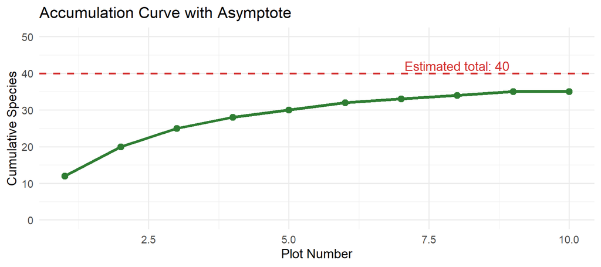

```r
# Our data from before
curve_data <- data.frame(
  plot = 1:10,
  total = cumsum(c(12, 8, 5, 3, 2, 2, 1, 1, 1, 0))
)

# Estimate the asymptote (total species in the area)
estimated_total <- 40

# Plot with asymptote
ggplot(curve_data, aes(x = plot, y = total)) +
  geom_line(color = "#2E7D32", linewidth = 1.5) +
  geom_point(color = "#2E7D32", size = 3) +
  geom_hline(yintercept = estimated_total,
             linetype = "dashed", color = "#D32F2F", linewidth = 1) +
  annotate("text", x = 8, y = estimated_total + 2,
           label = paste("Estimated total:", estimated_total),
           color = "#D32F2F") +
  labs(title = "Accumulation Curve with Asymptote",
       x = "Plot Number",
       y = "Cumulative Species") +
  theme_minimal(base_size = 14) +
  ylim(0, 50)
```

```r
# How complete is our sampling?
found <- max(curve_data$total)
completeness <- (found / estimated_total) * 100

cat("Species found:", found, "\n")
```

```
## Species found: 35
```

```r
cat("Estimated total:", estimated_total, "\n")
```

```
## Estimated total: 40
```

```r
cat("Sampling completeness:", round(completeness, 1), "%\n")
```

```
## Sampling completeness: 87.5 %
```

With 10 plots, we found 35 of an estimated 40 species (87.5% complete).

Mit 10 Plots haben wir 35 von geschätzten 40 Arten gefunden (87.5% vollständig).

# Exercise 5: Exploring Native vs. AlienÜbung 5: Heimisch vs. Alien erkunden

#### Filtering and Counting by Status

#### Filtern und Zählen nach Status

```r
# Load the data
species <- read.csv("../data/austria_species.csv")

# Count by status
table(species$STATUS)
```

```
##
## native    neo
## 826055  26020
```

```r
# Filter native species only
native <- species[species$STATUS == "native", ]
nrow(native)
```

```
## [1] 826055
```

```r
# Filter neophyte species only
neo <- species[species$STATUS == "neo", ]
nrow(neo)
```

```
## [1] 26020
```

```r
# How many UNIQUE native species?
n_native <- length(unique(native$WFO_TAXON))
n_native
```

```
## [1] 2378
```

```r
# How many UNIQUE neophyte species?
n_neo <- length(unique(neo$WFO_TAXON))
n_neo
```

```
## [1] 323
```

```r
# Ratio
cat("Ratio of native to neo:", round(n_native / n_neo, 1), ": 1\n")
```

```
## Ratio of native to neo: 7.4 : 1
```

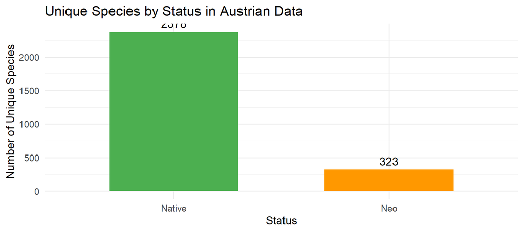

```r
# Visualize the difference
status_counts <- data.frame(
  Status = c("Native", "Neo"),
  Count = c(n_native, n_neo)
)

ggplot(status_counts, aes(x = Status, y = Count, fill = Status)) +
  geom_col(width = 0.6) +
  geom_text(aes(label = Count), vjust = -0.5, size = 5) +
  scale_fill_manual(values = c("Neo" = "#FF9800", "Native" = "#4CAF50")) +
  labs(title = "Unique Species by Status in Austrian Data",
       y = "Number of Unique Species") +
  theme_minimal(base_size = 14) +
  theme(legend.position = "none")
```

There are about 7 times more native species than neophyte species in our dataset.

**Tomorrow:** We’ll build separate accumulation curves for each group and compare their shapes!

Es gibt etwa 7 mal mehr heimische als Neophyten-Arten in unserem Datensatz.

**Morgen:** Wir werden separate Akkumulationskurven für jede Gruppe bauen und ihre Formen vergleichen!

# Summary: R Functions LearnedZusammenfassung: Gelernte R-Funktionen

| Function | Purpose_EN | Purpose_DE |
| --- | --- | --- |
| c() | Combine values into vector | Werte zu Vektor kombinieren |
| length() | Count elements | Elemente zählen |
| unique() | Find unique values | Eindeutige Werte finden |
| read.csv() | Load CSV file | CSV-Datei laden |
| head() | View first rows | Erste Zeilen anzeigen |
| names() | Column names | Spaltennamen |
| nrow() | Number of rows | Zeilenanzahl |
| cumsum() | Cumulative sum | Kumulative Summe |
| table() | Count by category | Nach Kategorie zählen |